# Part II - Ford GoBike Data System

## Dataset Overview

> Ford GoBike Data is a datset with 16 columns and 183412 rows. The dataset contains information about the Bike Sharing System in San Francisco Area. The data pulled covered entries in February 2019. There bike station names, latitude and longitude of the stations, duration of the bike taken from the station, biker year of birth etc

## Users Gender Percentage

> The dataset contains information about users(both male and female). All these users are riding bicyccles. It is important to know the percentage of the male and that of the female. It is also noted that there are others that did not declare their gender. I found out that the male are more in number. Up to 74.6% percent of the whole members are male. There are few that did not specify gender, 2.1% percent of them. The male patronises the bicycle share system

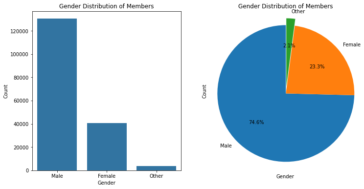

## Age of the Users

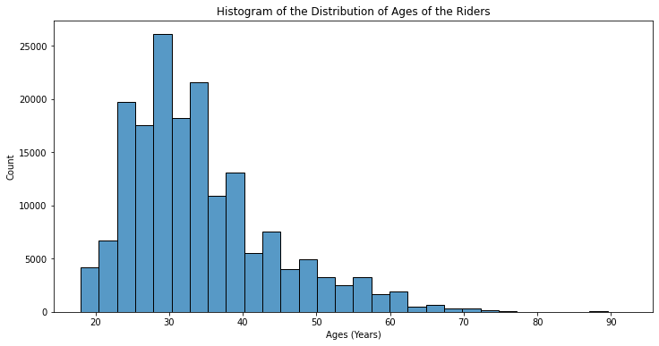

## Is peak time for males different from the females?

> Gender sometimes plays it role in the life of people. We need to find out if there is difference in the peak hours female and male get bicycle from the stations. If there is, we need to look more to know why. Looking at what we have, the peak time for males is almost the same for females. There is no significant difference observed in the peak hour for taking bikesThe peak time for males is almost the same for females. There is no significant difference observed in the peak hour for taking bikes

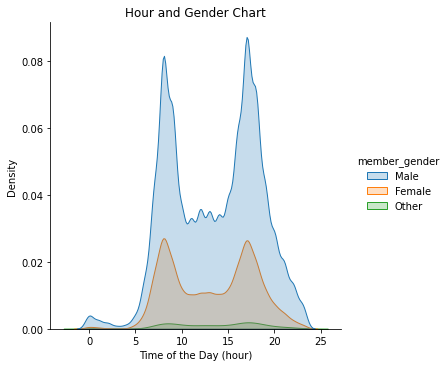

## Is the peak days for males different from females for taking bikes?

> Still with what we have above, let us look the days females prefer to make use of bikes. Could this be a different set of days for males? Well, from the information available to us, I could not find significant difference in peak days. Following the shape of the plot, they have similar peak days for picking bikes

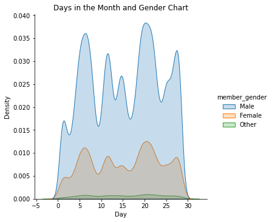